# Anne Byrne

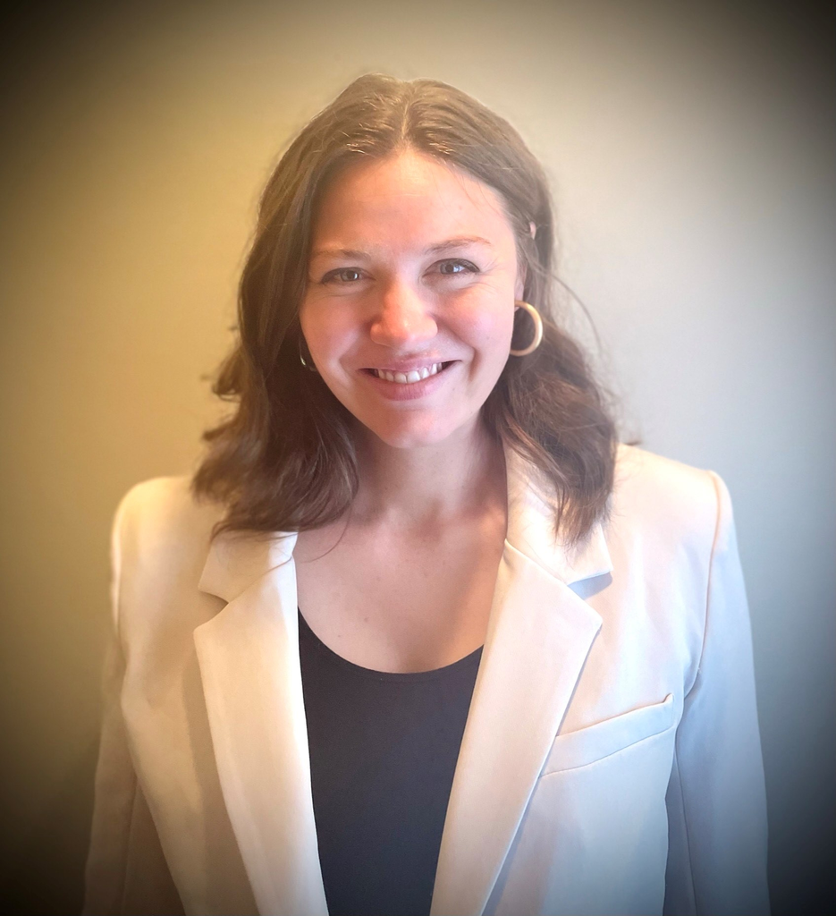

**Bio:** Anne Byrne is a research agricultural economist in the ERS Food Markets Branch. Her research focuses on how consumers access and afford food. She analyzes economic features of the food landscape—including retail food markets, food banks, and other private food assistance services—and geographic variation of food availability. She also analyzes consumer food behavior, particularly among low income and resource limited households, including use of food assistance and substitution across products and outlets. Her work has been published in the American Journal of Agricultural Economics, Food Policy, and Applied Economic Perspectives and Policy, among other outlets.

**Presentation Title:** Food Prices from the Consumer’s Point of View